# Stat418 HW3

Luxi Li

5/17/2017

### Part 1. Data Loading:

Dataset is from UCI Machine Learning Repository. Website: https://archive.ics.uci.edu/ml/machine-learning-databases/adult/ The goal is to predict whether income exceeds $50K/yr based on census salary dataset.

Here is varaible information about the data set:

- age: The age of the individual
- workclass: The type of employer the individual has.
- fnlwgt: Number of people the census takers believe that observation represents.
- education: Highest level of education achieved for that individual
- education_num: Number of years of education
- marital: Marital status of the individual
- occupation: Occupation of the individual
- relationship: Contains family relationship values
- race: descriptions of the individuals race.
- capital_gain: Capital gains
- capital_loss: Capital Losses
- hours_per_week: Hours worked per week
- native_country: Country of origin for person
- salary_level: Boolean Variable. Whether or not the person makes more than $50,000 per annum income.

I try some machine learning algorithms, such as Logistic Regression, Random Forest and Generalized Boosted Regression.

```r
setwd("~/Desktop/STAT 418/Stat418HW3")
data = read.csv("~/Desktop/Stat418HW3/adult.data.txt", header = FALSE, fill = TRUE)
data.1 = read.csv("~/Desktop/Stat418HW3/adult.test.txt", header = FALSE, fill = TRUE)

colnames(data) = c("age", "workclass", "fnlwgt", "educaton","education_num",
                   "marital_status", "occupation",
                   "relationship","race", "sex","capital_gain","capital_loss",
                   "hours_per_week", "native_country", "salary_level")

colnames(data.1) = c("age", "workclass", "fnlwgt", "educaton","education_num",
                   "marital_status", "occupation",
                   "relationship","race", "sex","capital_gain","capital_loss",
                   "hours_per_week", "native_country", "salary_level")
data.1 = data.1[-1,]
data.1$salary_level = as.character(data.1$salary_level)
data.1$salary_level[data.1$salary_level == " <=50K."] = " <=50K"
data.1$salary_level[data.1$salary_level == " >50K."] = " >50K"
data.1$salary_level = as.factor(data.1$salary_level)

total = rbind(data, data.1)
```

Since the adult data is separated to two text files, I combine them together and then clean data at next part.

### Part 2 Data Cleaning:

Looking into summary of the data set, age is in type of character, which should be numeric, and some variables are already in type of factors.

```r
summary(total)
```

```
##      age                        workclass         fnlwgt
##  Length:48842        Private         :33906   Min.   :  12285
##  Class :character    Self-emp-not-inc: 3862   1st Qu.: 117550
##  Mode  :character    Local-gov       : 3136   Median : 178144
##                      ?               : 2799   Mean   : 189664
##                      State-gov       : 1981   3rd Qu.: 237642
##                      Self-emp-inc    : 1695   Max.   :1490400
##                     (Other)          : 1463
##           educaton     education_num                  marital_status
##   HS-grad     :15784   Min.   : 1.00    Married-civ-spouse   :22379
##   Some-college:10878   1st Qu.: 9.00    Never-married        :16117
##   Bachelors   : 8025   Median :10.00    Divorced             : 6633
##   Masters     : 2657   Mean   :10.08    Separated            : 1530
##   Assoc-voc   : 2061   3rd Qu.:12.00    Widowed              : 1518
##   11th        : 1812   Max.   :16.00    Married-spouse-absent:  628
##  (Other)      : 7625                   (Other)               :   37
##             occupation             relationship
##   Prof-specialty : 6172    Husband       :19716
##   Craft-repair   : 6112    Not-in-family :12583
##   Exec-managerial: 6086    Other-relative: 1506
##   Adm-clerical   : 5611    Own-child     : 7581
##   Sales          : 5504    Unmarried     : 5125
##   Other-service  : 4923    Wife          : 2331
##  (Other)         :14434                  :    0
##                   race            sex         capital_gain
##   Amer-Indian-Eskimo:  470    Female:16192   Min.   :    0
##   Asian-Pac-Islander: 1519    Male  :32650   1st Qu.:    0
##   Black             : 4685          :    0   Median :    0
##   Other             :  406                   Mean   : 1079
##   White             :41762                   3rd Qu.:    0
##                     :    0                   Max.   :99999
##
##   capital_loss    hours_per_week         native_country  salary_level
##  Min.   :   0.0   Min.   : 1.00    United-States:43832    <=50K:37155
##  1st Qu.:   0.0   1st Qu.:40.00    Mexico       :  951    >50K :11687
##  Median :   0.0   Median :40.00    ?            :  857
##  Mean   :  87.5   Mean   :40.42    Philippines  :  295
##  3rd Qu.:   0.0   3rd Qu.:45.00    Germany      :  206
##  Max.   :4356.0   Max.   :99.00    Puerto-Rico  :  184
##                                   (Other)       : 2517
```

I find that the data include some NA values showing as “?”, and the occurrences of “?” in each column is:

```r
for (i in c(1:dim(total)[2])){
 print(rbind(names(total)[i], sum(as.character(total[,i]) ==" ?" ) / nrow(total)))
}
```

```
##      [,1]
## [1,] "age"
## [2,] "0"
##      [,1]
## [1,] "workclass"
## [2,] "0.0573072355759387"
##      [,1]
## [1,] "fnlwgt"
## [2,] "0"
##      [,1]
## [1,] "educaton"
## [2,] "0"
##      [,1]
## [1,] "education_num"
## [2,] "0"
##      [,1]
## [1,] "marital_status"
## [2,] "0"
##      [,1]
## [1,] "occupation"
## [2,] "0.057511977396503"
##      [,1]
## [1,] "relationship"
## [2,] "0"
##      [,1]
## [1,] "race"
## [2,] "0"
##      [,1]
## [1,] "sex"
## [2,] "0"
##      [,1]
## [1,] "capital_gain"
## [2,] "0"
##      [,1]
## [1,] "capital_loss"
## [2,] "0"
##      [,1]
## [1,] "hours_per_week"
## [2,] "0"
##      [,1]
## [1,] "native_country"
## [2,] "0.0175463740223578"
##      [,1]
## [1,] "salary_level"
## [2,] "0"
```

```r
total = total[as.character(total$workclass) != " ?",]
total = total[as.character(total$occupation) != " ?",]
total = total[as.character(total$native_country) != " ?",]
dim(total)
```

```
## [1] 45222    15
```

Now I get the data exclude all NA values.

I remove education_num and fnlwgt, since education_num and education are same implementation which is correlated and fnlwgt final weight estimate refers to population totals so it is diminished impact on salary level:

```r
total$fnlwgt = NULL
total$education_num = NULL
```

Then, split the data to train and test data set for future prediction. I use train data to get model, and cross validation, then use test data to predict salary level. Higher accuracy means better model fitted.

```r
set.seed(100)
spec = c(train = .6, test = .4)

g = sample(cut(
  seq(nrow(total)),
  nrow(total)*cumsum(c(0,spec)),
  labels = names(spec)
))
res = split(total, g)
addmargins(prop.table(table(g)))
```

```
## g
##     train      test       Sum
## 0.5999956 0.4000044 1.0000000
```

```r
train = res$train
test = res$test
```

I split the data in 6:4, which means that 60 percent of data to train data and left as test data.

Now I get the cleaned train and test data.

### Part 3 Exploratory Analysis:

Looking into age,which has wide range and variability. The distribution and mean are quite different for income level <=50K and >50K, implying that age will be a good predictor of salary level:

```r
train$age = as.numeric(train$age)
```

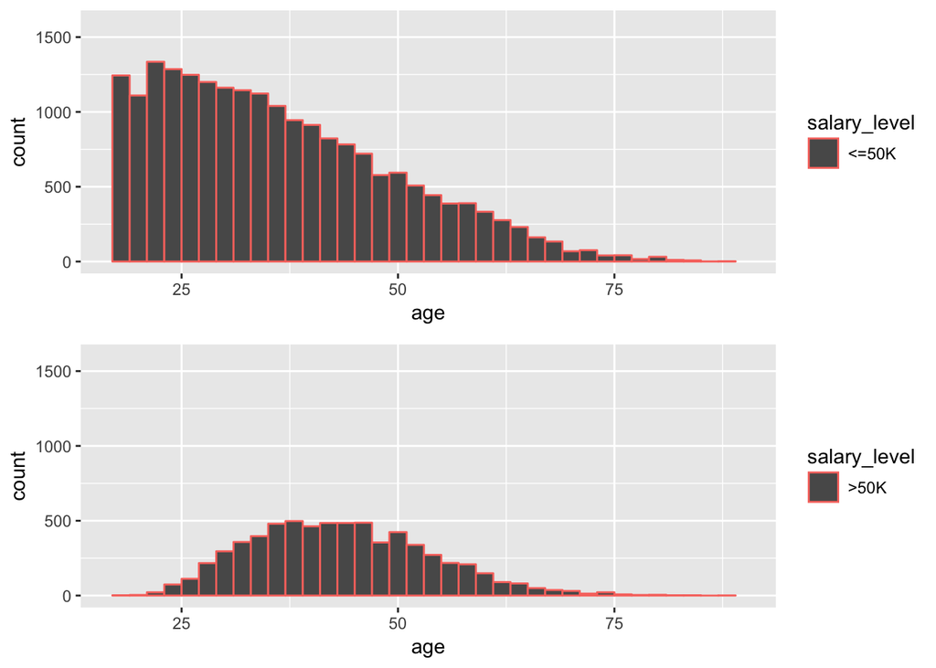

```r
library(gridExtra)
library(grid)
library(ggplot2)
library(lattice)
below = (train$salary_level == " <=50K")

hist1 = qplot (age, data = train[below,], margins = TRUE,
           binwidth = 2, xlim = c (min (train$age), max (train$age)), ylim = c (0, 1600), colour = salary_level)

hist2 = qplot (age, data = train[!below,], margins = TRUE,
           binwidth = 2, xlim = c (min (train$age), max (train$age)), ylim = c (0, 1600), colour = salary_level)

grid.arrange (hist1, hist2, nrow = 2)
```

This two histogram also shows that age is important variable to the model.

The below shows that there is no correlation between the continuous variables and that they are independent of each other:

```r
corMat = cor (train[, c("age",  "capital_gain", "capital_loss", "hours_per_week")])
diag (corMat) = 0
corMat
```

```
##                       age capital_gain capital_loss hours_per_week
## age            0.00000000   0.08579930   0.05152199     0.10381979
## capital_gain   0.08579930   0.00000000  -0.03200692     0.08640801
## capital_loss   0.05152199  -0.03200692   0.00000000     0.05930672
## hours_per_week 0.10381979   0.08640801   0.05930672     0.00000000
```

```r
table (train[,c("sex", "salary_level")])
```

```
##          salary_level
## sex        <=50K  >50K
##    Female   7846   985
##    Male    12589  5713
##                0     0
```

Next, I check the variables that are factors

```r
dim(train)
```

```
## [1] 27133    13
```

```r
for (i in c(1:13)){
 print(is.factor(train[,i]))
}
```

```
## [1] FALSE
## [1] TRUE
## [1] TRUE
## [1] TRUE
## [1] TRUE
## [1] TRUE
## [1] TRUE
## [1] TRUE
## [1] FALSE
## [1] FALSE
## [1] FALSE
## [1] TRUE
## [1] TRUE
```

Following is the columns that are numeric variables:

```r
colnames(train)[c(1,9:11)]
```

```
## [1] "age"            "capital_gain"   "capital_loss"   "hours_per_week"
```

Then, I apply logistic regression in next part.

### Part 4 Logistic Regression:

To apply glmnet function, I transform dependent variables to a matrix. Set alpha as 1, Lasso Regression is used. The plot shows that with different lambda, how the coefficients distribute.

```r
library(Matrix)
library(foreach)
library(glmnet)
library(ROCR)
```

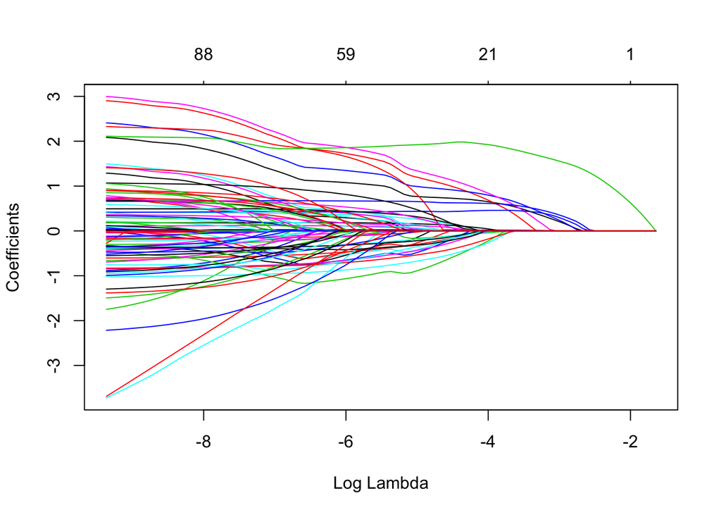

```r
age= train$age
workclass= train$workclass
educaton= train$educaton
marital_status= train$marital_status
occupation= train$occupation
relationship= train$relationship
race= train$race
sex= train$sex
capital_gain= train$capital_gain
capital_loss= train$capital_loss
hours_per_week= train$hours_per_week
native_country= train$native_country
salary_level= as.numeric(train$salary_level)
salary_level[salary_level == "1"] = 0
salary_level[salary_level == "2"] = 1

xfactors = model.matrix(salary_level ~ workclass+educaton+educaton+marital_status+
                       occupation +relationship+race+sex+native_country )[, -1]

x = as.matrix(data.frame(age, capital_gain, capital_loss, hours_per_week, xfactors))

model = glmnet(x, y= as.factor(salary_level), family = "binomial", alpha  = 1)

plot(model, xvar="lambda")
```

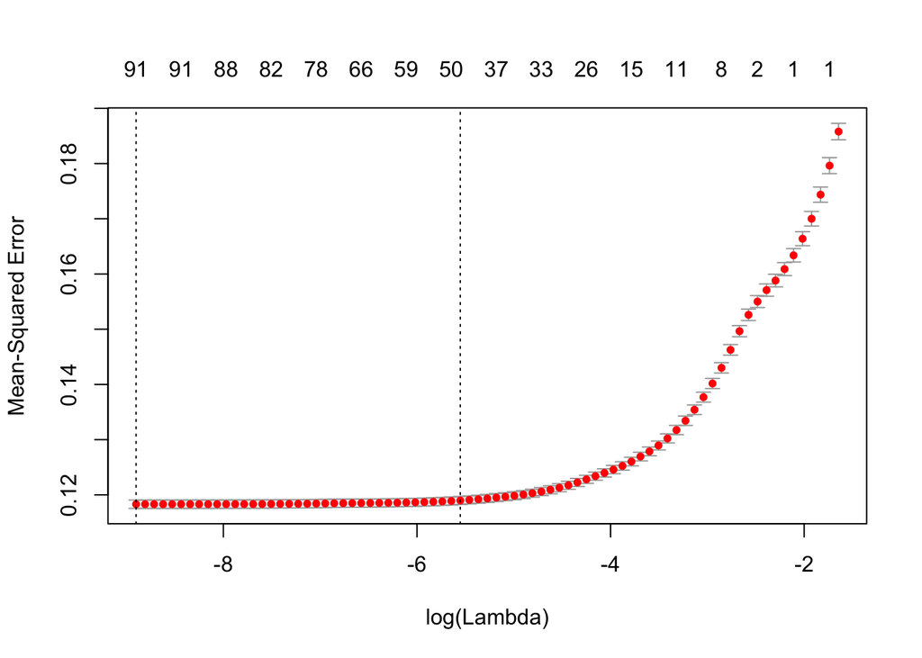

```r
cv.model = cv.glmnet(x, y=salary_level, alpha=1)
plot(cv.model)
```

```r
(best.lambda = cv.model$lambda.min)
```

```
## [1] 0.0001361987
```

From the plot, left vertical line shows when the CV-error curve hits its minimum. The right vertical line shows the most regularized model with CV-error within 1 standard deviation of the minimum. I also extract optimal lambda.

```r
fit  = glmnet(x, y = salary_level, alpha = 1, lambda = best.lambda  )
```

Then, I use test data to get AUC rate.

Same as previous steps, I get a matrix-formed data and then apply them to model.

```r
library(Matrix)
library(foreach)
library(glmnet)
library(ROCR)

test$age = as.numeric(test$age)

age.1= test$age
workclass.1= test$workclass
educaton.1= test$educaton
marital_status.1= test$marital_status
occupation.1= test$occupation
relationship.1= test$relationship
race.1= test$race
sex.1= test$sex
capital_gain.1= test$capital_gain
capital_loss.1= test$capital_loss
hours_per_week.1= test$hours_per_week
native_country.1= test$native_country
salary_level.1= as.numeric(test$salary_level)
salary_level.1[salary_level.1 == "1"] = 0
salary_level.1[salary_level.1 == "2"] = 1

xfactors.1 = model.matrix(salary_level.1 ~ workclass.1+educaton.1+educaton.1+marital_status.1+
                       occupation.1 +relationship.1+race.1+sex.1+native_country.1 )[, -1]

x.1 = as.matrix(data.frame(age.1, capital_gain.1, capital_loss.1, hours_per_week.1, xfactors.1))
```

Make prediction and show how the model works.

```r
phat =  predict(fit, newx = x.1, type = "response")

rocr_pred = prediction(phat, salary_level.1)

table(test$salary_level, ifelse(phat>0.5,1,0))
```

```
##
##              0     1
##    <=50K 12780   799
##    >50K   2159  2351
```

```r
(12761 + 2287)/nrow(test)
```

```
## [1] 0.8318868
```

```r
performance(rocr_pred, "auc")@y.values[[1]]
```

```
## [1] 0.8906479
```

Then, I draw ROC curve. The curve close to the left-hand and top border of the ROC space.

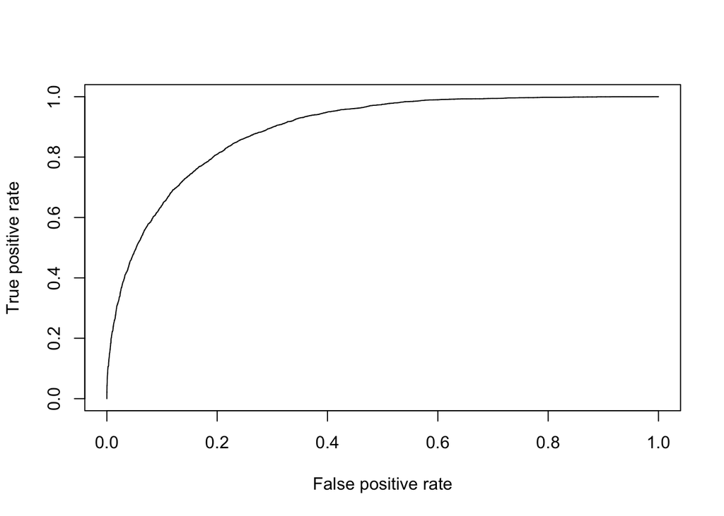

```r
library(ggplot2)
plot(performance(rocr_pred, "tpr", "fpr"))
```

### Part 5 Random Forest:

After doing regression method, I try classification method.

I first use tuneRF to find out optimal number of variables randomly sampled as candidates at each split(mtry).

ntreeTry specifies the number of trees to make using this function. By trying out different numbers for mtry, I get same result that optimized mtry is 4.

```
## mtry = 3  OOB error = 18.14%
## Searching left ...
## mtry = 2     OOB error = 18.05%
## 0.005079236 0.01
## Searching right ...
## mtry = 4     OOB error = 17.9%
## 0.01300284 0.01
## mtry = 6     OOB error = 18.21%
## -0.01729107 0.01
```

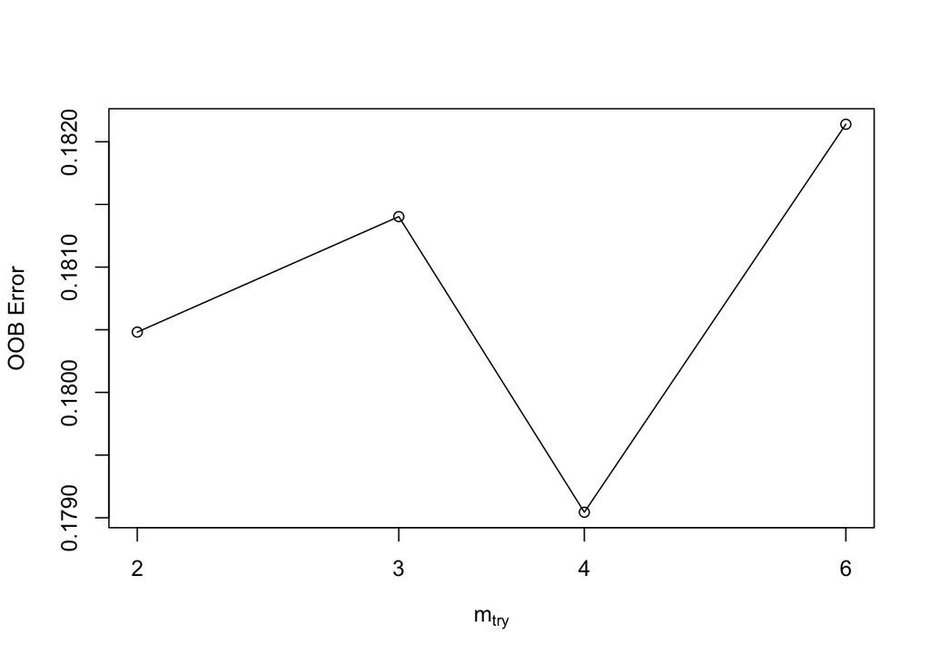

```r
set.seed(100)
library(randomForest)
library(ROCR)
bestmtry = tuneRF(train[,-13],train$salary_level, ntreeTry=100,
     stepFactor=1.5,improve=0.01, trace=TRUE, plot=TRUE, dobest=FALSE)
```

```r
#bestmtry.1 = tuneRF(train[,-13],train$salary_level, ntreeTry=400, stepFactor=1.5,improve=0.01, trace=TRUE, plot=TRUE, dobest=FALSE)
#bestmtry.1 = tuneRF(train[,-13],train$salary_level, ntreeTry=200, stepFactor=1.5,improve=0.01, trace=TRUE, plot=TRUE, dobest=FALSE)
#bestmtry.1 = tuneRF(train[,-13],train$salary_level, ntreeTry=500, stepFactor=1.5,improve=0.01, trace=TRUE, plot=TRUE, dobest=FALSE)
```

Then, use random forest to train data:

```r
rf = randomForest(salary_level ~ .,data= train, mtry=4, ntree=1000)
```

Finally, we can evaluate the performance of the random forest for classification.

```r
library(lattice)
library(ggplot2)
library(ROCR)
library(gplots)
rf.pr = predict(rf,type="prob",newdata=test)[,2]
rf.pred = prediction(rf.pr, test$salary_level)
rf.perf = performance(rf.pred,"tpr","fpr")
performance(rf.pred, "auc")@y.values[[1]]
```

```
## [1] 0.8667132
```

```r
a = table(ifelse(rf.pr>0.5,1,0), test$salary_level)
(a[1,1] + a[2,2]) / nrow(test)
```

```
## [1] 0.8167947
```

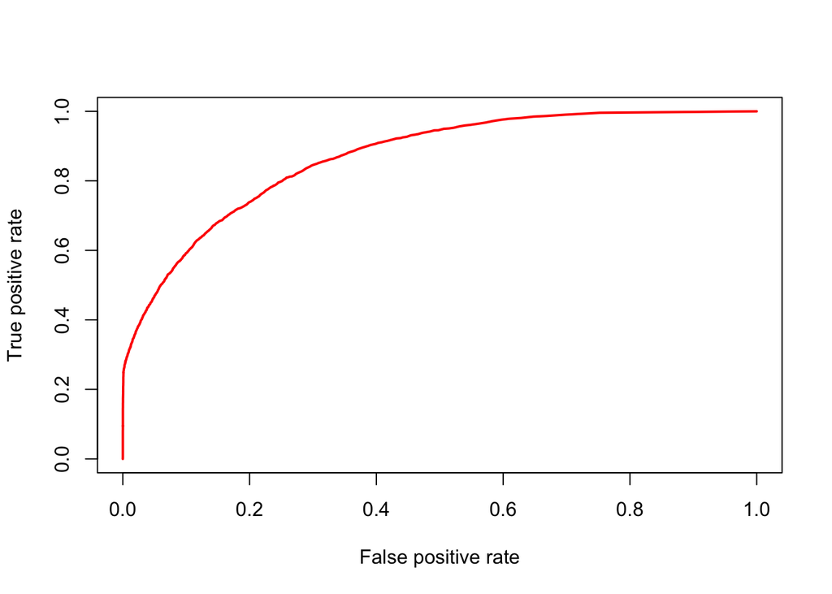

```r
plot(rf.perf,col=2,lwd=2)
```

We get the AUC rate of 87 percent, accuracy rate is 82 percent.

Then, I evaluate what variables are most important in generating the forest.

```r
importance(rf)
```

```
##                MeanDecreaseGini
## age                   1248.1708
## workclass              371.5728
## educaton              1070.4673
## marital_status         893.0223
## occupation             886.1953
## relationship          1175.0326
## race                   140.1611
## sex                    109.3512
## capital_gain          1123.6114
## capital_loss           338.8468
## hours_per_week         741.0247
## native_country         239.9142
```

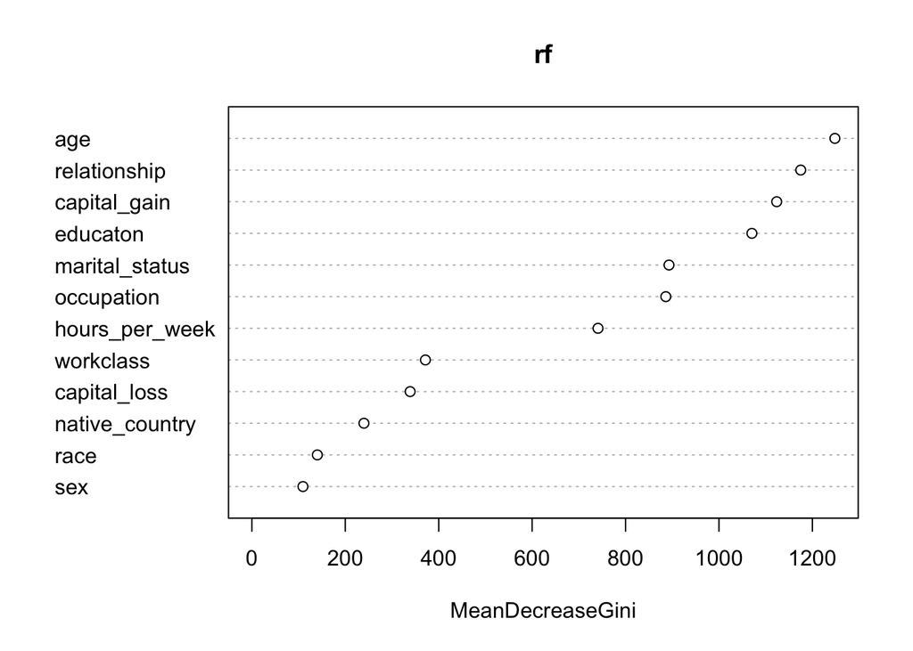

```r
varImpPlot(rf)
```

The plot shows that the most important variables included age, capital gain, education, marital status and relationship. Variables like race and sex are less important.

Next, I try Gradient Boosting by using Xgboost package.

### Part 6 Gradient Boosting Trees:

Since Xgboost manages only numeric vectors, I use the transformed matrix data in model.

At first, I try xgboost function which is a simpler interface compared to xgb.train.

```r
library(xgboost)
library(ROCR)
n_proc = parallel::detectCores()
md = xgboost(data = x, label = salary_level,
                nthread = n_proc, nround = 1, max_depth = 10,
                num_parallel_tree = 500, subsample = 0.5,
                colsample_bytree = 0.7,
                save_period = NULL)
phat.xgboost = predict(md, newdata = x.1)

rocr_pred = prediction(phat.xgboost, salary_level.1)

performance(rocr_pred, "auc")@y.values[[1]] #0.91
```

```
## [1] 0.9099897
```

```r
table(test$salary_level, ifelse(phat.xgboost>0.5,1,0))
```

```
##
##              0     1
##    <=50K 12801   778
##    >50K   1819  2691
```

```r
(12748 + 2724)/nrow(test)
```

```
## [1] 0.8553264
```

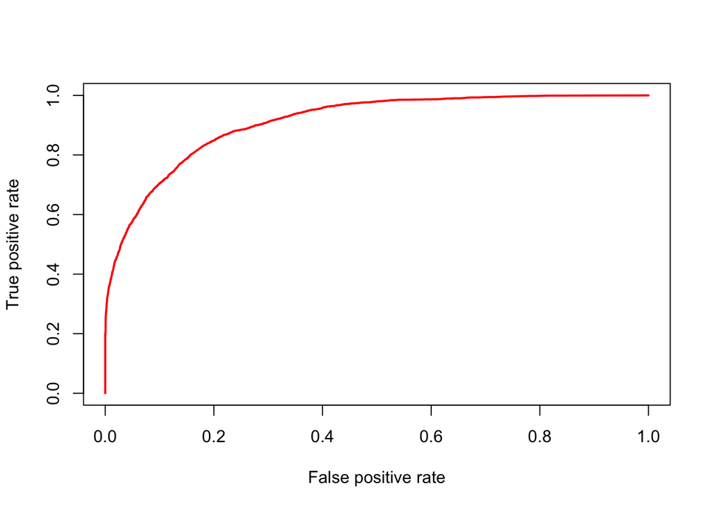

```r
perf = performance(rocr_pred,"tpr","fpr")
plot(perf,col=2,lwd=2)
```

The fitted model prediction AUC rate is 91 percent, and accuracy rate is 86 percent.

```r
set.seed(100)
library(xgboost)
dtrain <- xgb.DMatrix(data = x,label = salary_level)
dtest <- xgb.DMatrix(data = x.1,label= salary_level.1)

params <- list(booster = "gbtree", objective = "binary:logistic", eta=0.3, gamma=0, max_depth=6, min_child_weight=1, subsample=1, colsample_bytree=1)

xgbcv <- xgb.cv( params = params, data = dtrain, nrounds = 100, nfold = 5, showsd = T, stratified = T, print.every.n = 10, early.stop.round = 10, maximize = F)
```

```
## Multiple eval metrics are present. Will use test_error for early stopping.
## Will train until test_error hasn't improved in 10 rounds.
##
## Stopping. Best iteration:
```

```r
xgb1 <- xgb.train (params = params, data = dtrain, nrounds = 37, watchlist = list(val=dtest,train=dtrain), print.every.n = 10, early.stop.round = 10, maximize = F , eval_metric = "error")
```

```
## Multiple eval metrics are present. Will use train_error for early stopping.
## Will train until train_error hasn't improved in 10 rounds.
##
```

```r
phat.gbm = predict(xgb1, newdata = x.1)

rocr_pred_1 = prediction(phat.gbm, salary_level.1)
performance(rocr_pred_1, "auc")@y.values[[1]]
```

```
## [1] 0.9244866
```

```r
table(test$salary_level, ifelse(phat.gbm>0.5,1,0))
```

```
##
##              0     1
##    <=50K 12819   760
##    >50K   1620  2890
```

```r
(12768 + 2857)/nrow(test)
```

```
## [1] 0.8637846
```

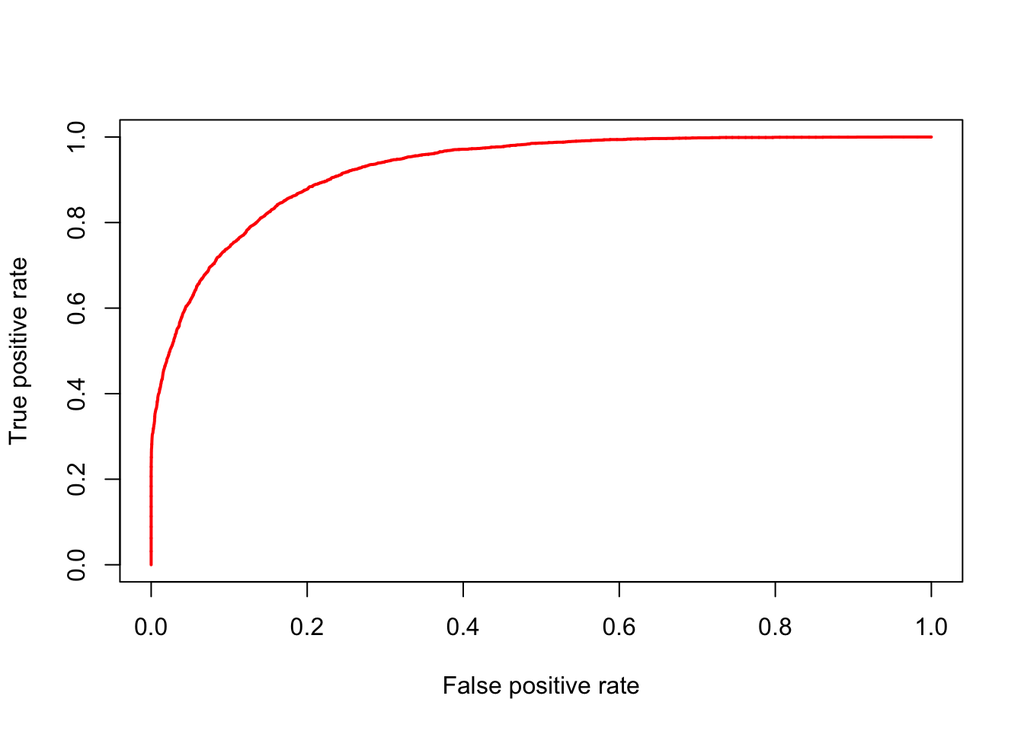

```r
perf = performance(rocr_pred_1,"tpr","fpr")
plot(perf,col=2,lwd=2)
```

With AUC rate of 92 percent and accuracy rate of 86 percent, this model performes better.

```r
xgb_param_adult = list(
  nrounds = c(700),
  eta = 0.057,#eta between(0.01-0.2)
  max_depth = 4, #values between(3-10)
  subsample = 0.7,#values between(0.5-1)
  colsample_bytree = 0.7,#values between(0.5-1)
  num_parallel_tree=1,
  objective='binary:logistic',
  min_child_weight = 1,
  booster='gbtree'
)

xgb.fit = xgb.train(xgb_param_adult, dtrain, 500)

preds = predict(xgb.fit, newdata=x.1)
table(test$salary_level, ifelse(preds>0.5,1,0))
```

```
##
##              0     1
##    <=50K 12779   800
##    >50K   1579  2931
```

```r
(12727 + 2929)/nrow(test)
```

```
## [1] 0.8654984
```

```r
rocr_pred.2 <- prediction(preds, salary_level.1)
performance(rocr_pred.2, "auc")@y.values[[1]]
```

```
## [1] 0.9255937
```

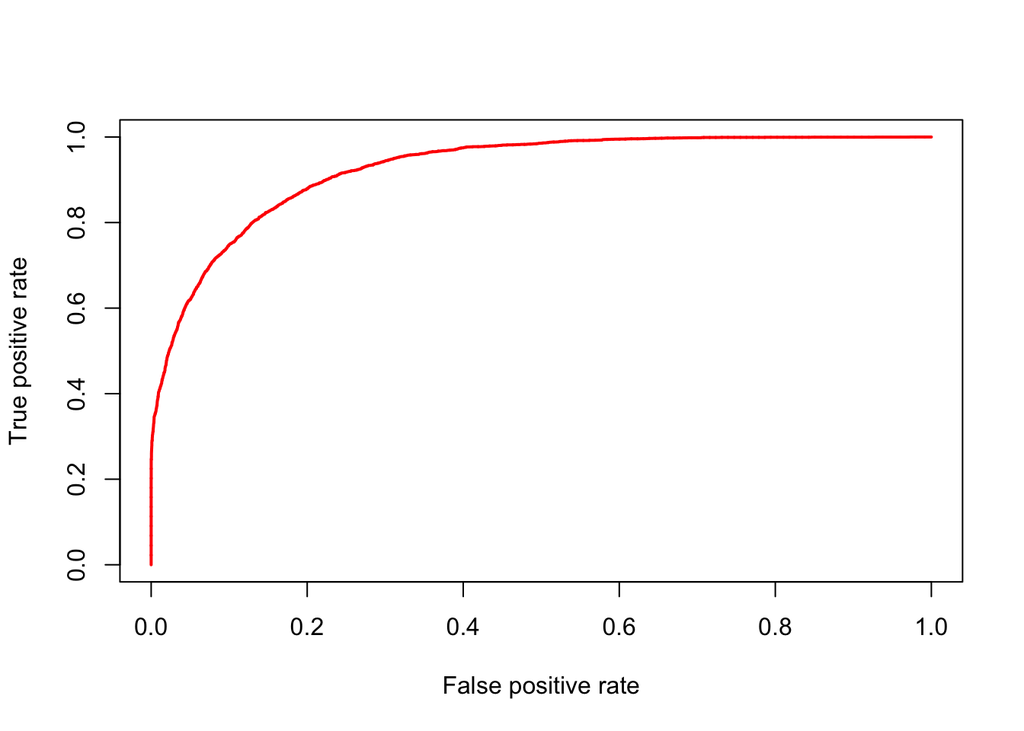

```r
perf = performance(rocr_pred.2 ,"tpr","fpr")
plot(perf,col=2,lwd=2)
```

With AUC rate of 93 percent and accuracy rate of 87 percent, this model performes slightly better than last one.

### Part 8 Conclusion:

In this project, I approach several models and implement them on a classifier dataset, addressing several issues like hyper-parameters tuning to ultimately boosting accuracy of models. Ultimately, xgboost performes best. XGBOOST performes amazingly especially upon hyper- parameter tuning.